# Lab3

Eduarda Espindola

11/25/2018

## Introduction:

## Data Loading and Cleaning

First of all, we must load our data into R:

```r
crime <- read.csv("../crime_v2.csv", header = T, as.is = T)
```

Now, we have the description for our variables, and how they were calculated / proxied, which will allow us to understand the expected data type and the theoretical range of values.

Now, we can take a look at how our data is structured:

```r
head(crime)
```

```
##   county year    crmrte   prbarr     prbconv  prbpris avgsen      polpc
## 1      1   87 0.0356036 0.298270 0.527595997 0.436170   6.71 0.00182786
## 2      3   87 0.0152532 0.132029 1.481480002 0.450000   6.35 0.00074588
## 3      5   87 0.0129603 0.444444 0.267856985 0.600000   6.76 0.00123431
## 4      7   87 0.0267532 0.364760 0.525424004 0.435484   7.14 0.00152994
## 5      9   87 0.0106232 0.518219 0.476563007 0.442623   8.22 0.00086018
## 6     11   87 0.0146067 0.524664 0.068376102 0.500000  13.00 0.00288203
##     density    taxpc west central urban pctmin80     wcon     wtuc
## 1 2.4226327 30.99368    0       1     0 20.21870 281.4259 408.7245
## 2 1.0463320 26.89208    0       1     0  7.91632 255.1020 376.2542
## 3 0.4127659 34.81605    1       0     0  3.16053 226.9470 372.2084
## 4 0.4915572 42.94759    0       1     0 47.91610 375.2345 397.6901
## 5 0.5469484 28.05474    1       0     0  1.79619 292.3077 377.3126
## 6 0.6113361 35.22974    1       0     0  1.54070 250.4006 401.3378
##       wtrd     wfir     wser   wmfg   wfed   wsta   wloc        mix
## 1 221.2701 453.1722 274.1775 334.54 477.58 292.09 311.91 0.08016878
## 2 196.0101 258.5650 192.3077 300.38 409.83 362.96 301.47 0.03022670
## 3 229.3209 305.9441 209.6972 237.65 358.98 331.53 281.37 0.46511629
## 4 191.1720 281.0651 256.7214 281.80 412.15 328.27 299.03 0.27362204
## 5 206.8215 289.3125 215.1933 290.89 377.35 367.23 342.82 0.06008584
## 6 187.8255 258.5650 237.1507 258.60 391.48 325.71 275.22 0.31952664
##      pctymle
## 1 0.07787097
## 2 0.08260694
## 3 0.07211538
## 4 0.07353726
## 5 0.07069755
## 6 0.09891920
```

Now that we have our data loaded, we are going to do some basic sanity checks in out data. We will start by checking for rows with NA values:

```r
crime[is.na(crime$county),]
```

```
##    county year crmrte prbarr prbconv prbpris avgsen polpc density taxpc
## 92     NA   NA     NA     NA              NA     NA    NA      NA    NA
## 93     NA   NA     NA     NA              NA     NA    NA      NA    NA
## 94     NA   NA     NA     NA              NA     NA    NA      NA    NA
## 95     NA   NA     NA     NA              NA     NA    NA      NA    NA
## 96     NA   NA     NA     NA              NA     NA    NA      NA    NA
## 97     NA   NA     NA     NA       `      NA     NA    NA      NA    NA
##    west central urban pctmin80 wcon wtuc wtrd wfir wser wmfg wfed wsta
## 92   NA      NA    NA       NA   NA   NA   NA   NA   NA   NA   NA   NA
## 93   NA      NA    NA       NA   NA   NA   NA   NA   NA   NA   NA   NA
## 94   NA      NA    NA       NA   NA   NA   NA   NA   NA   NA   NA   NA
## 95   NA      NA    NA       NA   NA   NA   NA   NA   NA   NA   NA   NA
## 96   NA      NA    NA       NA   NA   NA   NA   NA   NA   NA   NA   NA
## 97   NA      NA    NA       NA   NA   NA   NA   NA   NA   NA   NA   NA
##    wloc mix pctymle
## 92   NA  NA      NA
## 93   NA  NA      NA
## 94   NA  NA      NA
## 95   NA  NA      NA
## 96   NA  NA      NA
## 97   NA  NA      NA
```

We observe that we have 6 observations with NA’s in all of the variables, and therefore, add no information to our analysis. For that reason, we will discard those observations

```r
crime<-crime[!is.na(crime$county),]
```

Now that we have removed the NAs, we should check for duplicate observations:

```r
crime[duplicated(crime),]
```

```
##    county year    crmrte   prbarr     prbconv  prbpris avgsen      polpc
## 89    193   87 0.0235277 0.266055 0.588859022 0.423423   5.86 0.00117887
##      density    taxpc west central urban pctmin80     wcon     wtuc
## 89 0.8138298 28.51783    1       0     0  5.93109 285.8289 480.1948
##        wtrd     wfir     wser   wmfg   wfed   wsta   wloc       mix
## 89 268.3836 365.0196 295.9352 295.63 468.26 337.88 348.74 0.1105016
##       pctymle
## 89 0.07819394
```

We see that county 193 appears twice in our dataset. For that reason, we are discarding one, and therefore, keeping only one observation of county 193 in our dataset.

```r
crime<-crime[!duplicated(crime),]
```

Now we go to a deeper analysis. By the description of the variables and how they are calculated, we expect them to be in certain format. Let’s check how R loaded the variables.

```r
str(crime)
```

```
## 'data.frame':    90 obs. of  25 variables:
##  $ county  : int  1 3 5 7 9 11 13 15 17 19 ...
##  $ year    : int  87 87 87 87 87 87 87 87 87 87 ...
##  $ crmrte  : num  0.0356 0.0153 0.013 0.0268 0.0106 ...
##  $ prbarr  : num  0.298 0.132 0.444 0.365 0.518 ...
##  $ prbconv : chr  "0.527595997" "1.481480002" "0.267856985" "0.525424004" ...
##  $ prbpris : num  0.436 0.45 0.6 0.435 0.443 ...
##  $ avgsen  : num  6.71 6.35 6.76 7.14 8.22 ...
##  $ polpc   : num  0.001828 0.000746 0.001234 0.00153 0.00086 ...
##  $ density : num  2.423 1.046 0.413 0.492 0.547 ...
##  $ taxpc   : num  31 26.9 34.8 42.9 28.1 ...
##  $ west    : int  0 0 1 0 1 1 0 0 0 0 ...
##  $ central : int  1 1 0 1 0 0 0 0 0 0 ...
##  $ urban   : int  0 0 0 0 0 0 0 0 0 0 ...
##  $ pctmin80: num  20.22 7.92 3.16 47.92 1.8 ...
##  $ wcon    : num  281 255 227 375 292 ...
##  $ wtuc    : num  409 376 372 398 377 ...
##  $ wtrd    : num  221 196 229 191 207 ...
##  $ wfir    : num  453 259 306 281 289 ...
##  $ wser    : num  274 192 210 257 215 ...
##  $ wmfg    : num  335 300 238 282 291 ...
##  $ wfed    : num  478 410 359 412 377 ...
##  $ wsta    : num  292 363 332 328 367 ...
##  $ wloc    : num  312 301 281 299 343 ...
##  $ mix     : num  0.0802 0.0302 0.4651 0.2736 0.0601 ...
##  $ pctymle : num  0.0779 0.0826 0.0721 0.0735 0.0707 ...
```

```r
crime$prbconv <- as.numeric(as.character(crime$prbconv))
```

For now, the basic cleaning has been done, however, we should move up to assessing any other oddities with the data, regarding the values it should theoretically assume and also analyzing outliers.

```r
library(summarytools)
summary(crime[,3:25])
```

```
##      crmrte             prbarr           prbconv           prbpris
##  Min.   :0.005533   Min.   :0.09277   Min.   :0.06838   Min.   :0.1500
##  1st Qu.:0.020604   1st Qu.:0.20495   1st Qu.:0.34422   1st Qu.:0.3642
##  Median :0.030002   Median :0.27146   Median :0.45170   Median :0.4222
##  Mean   :0.033510   Mean   :0.29524   Mean   :0.55086   Mean   :0.4106
##  3rd Qu.:0.040249   3rd Qu.:0.34487   3rd Qu.:0.58513   3rd Qu.:0.4576
##  Max.   :0.098966   Max.   :1.09091   Max.   :2.12121   Max.   :0.6000
##      avgsen           polpc              density            taxpc
##  Min.   : 5.380   Min.   :0.0007459   Min.   :0.00002   Min.   : 25.69
##  1st Qu.: 7.375   1st Qu.:0.0012378   1st Qu.:0.54718   1st Qu.: 30.73
##  Median : 9.110   Median :0.0014897   Median :0.97925   Median : 34.92
##  Mean   : 9.689   Mean   :0.0017080   Mean   :1.43567   Mean   : 38.16
##  3rd Qu.:11.465   3rd Qu.:0.0018856   3rd Qu.:1.56926   3rd Qu.: 41.01
##  Max.   :20.700   Max.   :0.0090543   Max.   :8.82765   Max.   :119.76
##       west           central           urban            pctmin80
##  Min.   :0.0000   Min.   :0.0000   Min.   :0.00000   Min.   : 1.284
##  1st Qu.:0.0000   1st Qu.:0.0000   1st Qu.:0.00000   1st Qu.:10.024
##  Median :0.0000   Median :0.0000   Median :0.00000   Median :24.852
##  Mean   :0.2444   Mean   :0.3778   Mean   :0.08889   Mean   :25.713
##  3rd Qu.:0.0000   3rd Qu.:1.0000   3rd Qu.:0.00000   3rd Qu.:38.183
##  Max.   :1.0000   Max.   :1.0000   Max.   :1.00000   Max.   :64.348
##       wcon            wtuc            wtrd            wfir
##  Min.   :193.6   Min.   :187.6   Min.   :154.2   Min.   :170.9
##  1st Qu.:250.8   1st Qu.:374.3   1st Qu.:190.7   1st Qu.:285.6
##  Median :281.2   Median :404.8   Median :203.0   Median :317.1
##  Mean   :285.4   Mean   :410.9   Mean   :210.9   Mean   :321.6
##  3rd Qu.:315.0   3rd Qu.:440.7   3rd Qu.:224.3   3rd Qu.:342.6
##  Max.   :436.8   Max.   :613.2   Max.   :354.7   Max.   :509.5
##       wser             wmfg            wfed            wsta
##  Min.   : 133.0   Min.   :157.4   Min.   :326.1   Min.   :258.3
##  1st Qu.: 229.3   1st Qu.:288.6   1st Qu.:398.8   1st Qu.:329.3
##  Median : 253.1   Median :321.1   Median :448.9   Median :358.4
##  Mean   : 275.3   Mean   :336.0   Mean   :442.6   Mean   :357.7
##  3rd Qu.: 277.6   3rd Qu.:359.9   3rd Qu.:478.3   3rd Qu.:383.2
##  Max.   :2177.1   Max.   :646.9   Max.   :598.0   Max.   :499.6
##       wloc            mix             pctymle
##  Min.   :239.2   Min.   :0.01961   Min.   :0.06216
##  1st Qu.:297.2   1st Qu.:0.08060   1st Qu.:0.07437
##  Median :307.6   Median :0.10095   Median :0.07770
##  Mean   :312.3   Mean   :0.12905   Mean   :0.08403
##  3rd Qu.:328.8   3rd Qu.:0.15206   3rd Qu.:0.08352
##  Max.   :388.1   Max.   :0.46512   Max.   :0.24871
```

```r
print(dfSummary(crime[,3:25]), method = 'render')
```

Data Frame Summary

crime

**N**: 90

| **No** | **Variable** | **Stats / Values** | **Freqs (% of Valid)** | **Graph** | **Valid** | **Missing** |
| --- | --- | --- | --- | --- | --- | --- |
| 1 | crmrte [numeric] | mean (sd) : 0.03 (0.02) min < med < max : 0.01 < 0.03 < 0.1 IQR (CV) : 0.02 (0.56) | 90 distinct values |  | 90 (100%) | 0 (0%) |
| 2 | prbarr [numeric] | mean (sd) : 0.3 (0.14) min < med < max : 0.09 < 0.27 < 1.09 IQR (CV) : 0.14 (0.47) | 90 distinct values |  | 90 (100%) | 0 (0%) |
| 3 | prbconv [numeric] | mean (sd) : 0.55 (0.35) min < med < max : 0.07 < 0.45 < 2.12 IQR (CV) : 0.24 (0.64) | 90 distinct values |  | 90 (100%) | 0 (0%) |
| 4 | prbpris [numeric] | mean (sd) : 0.41 (0.08) min < med < max : 0.15 < 0.42 < 0.6 IQR (CV) : 0.09 (0.2) | 86 distinct values |  | 90 (100%) | 0 (0%) |
| 5 | avgsen [numeric] | mean (sd) : 9.69 (2.83) min < med < max : 5.38 < 9.11 < 20.7 IQR (CV) : 4.09 (0.29) | 88 distinct values |  | 90 (100%) | 0 (0%) |
| 6 | polpc [numeric] | mean (sd) : 0 (0) min < med < max : 0 < 0 < 0.01 IQR (CV) : 0 (0.58) | 90 distinct values |  | 90 (100%) | 0 (0%) |
| 7 | density [numeric] | mean (sd) : 1.44 (1.52) min < med < max : 0 < 0.98 < 8.83 IQR (CV) : 1.02 (1.06) | 90 distinct values |  | 90 (100%) | 0 (0%) |
| 8 | taxpc [numeric] | mean (sd) : 38.16 (13.11) min < med < max : 25.69 < 34.92 < 119.76 IQR (CV) : 10.28 (0.34) | 90 distinct values |  | 90 (100%) | 0 (0%) |
| 9 | west [integer] | mean (sd) : 0.24 (0.43) min < med < max : 0 < 0 < 1 IQR (CV) : 0 (1.77) | 0 : 68 (75.6%) 1 : 22 (24.4%) |  | 90 (100%) | 0 (0%) |
| 10 | central [integer] | mean (sd) : 0.38 (0.49) min < med < max : 0 < 0 < 1 IQR (CV) : 1 (1.29) | 0 : 56 (62.2%) 1 : 34 (37.8%) |  | 90 (100%) | 0 (0%) |
| 11 | urban [integer] | mean (sd) : 0.09 (0.29) min < med < max : 0 < 0 < 1 IQR (CV) : 0 (3.22) | 0 : 82 (91.1%) 1 : 8 (8.9%) |  | 90 (100%) | 0 (0%) |
| 12 | pctmin80 [numeric] | mean (sd) : 25.71 (16.98) min < med < max : 1.28 < 24.85 < 64.35 IQR (CV) : 28.16 (0.66) | 90 distinct values |  | 90 (100%) | 0 (0%) |
| 13 | wcon [numeric] | mean (sd) : 285.35 (47.75) min < med < max : 193.64 < 281.16 < 436.77 IQR (CV) : 64.22 (0.17) | 90 distinct values |  | 90 (100%) | 0 (0%) |
| 14 | wtuc [numeric] | mean (sd) : 410.91 (77.36) min < med < max : 187.62 < 404.78 < 613.23 IQR (CV) : 66.35 (0.19) | 89 distinct values |  | 90 (100%) | 0 (0%) |
| 15 | wtrd [numeric] | mean (sd) : 210.92 (33.87) min < med < max : 154.21 < 202.99 < 354.68 IQR (CV) : 33.57 (0.16) | 90 distinct values |  | 90 (100%) | 0 (0%) |
| 16 | wfir [numeric] | mean (sd) : 321.62 (54) min < med < max : 170.94 < 317.13 < 509.47 IQR (CV) : 57.07 (0.17) | 87 distinct values |  | 90 (100%) | 0 (0%) |
| 17 | wser [numeric] | mean (sd) : 275.34 (207.4) min < med < max : 133.04 < 253.12 < 2177.07 IQR (CV) : 48.31 (0.75) | 90 distinct values |  | 90 (100%) | 0 (0%) |
| 18 | wmfg [numeric] | mean (sd) : 336.03 (88.23) min < med < max : 157.41 < 321.05 < 646.85 IQR (CV) : 71.3 (0.26) | 90 distinct values |  | 90 (100%) | 0 (0%) |
| 19 | wfed [numeric] | mean (sd) : 442.62 (59.95) min < med < max : 326.1 < 448.85 < 597.95 IQR (CV) : 79.47 (0.14) | 89 distinct values |  | 90 (100%) | 0 (0%) |
| 20 | wsta [numeric] | mean (sd) : 357.74 (43.29) min < med < max : 258.33 < 358.4 < 499.59 IQR (CV) : 53.88 (0.12) | 90 distinct values |  | 90 (100%) | 0 (0%) |
| 21 | wloc [numeric] | mean (sd) : 312.28 (28.13) min < med < max : 239.17 < 307.65 < 388.09 IQR (CV) : 31.55 (0.09) | 90 distinct values |  | 90 (100%) | 0 (0%) |
| 22 | mix [numeric] | mean (sd) : 0.13 (0.08) min < med < max : 0.02 < 0.1 < 0.47 IQR (CV) : 0.07 (0.63) | 90 distinct values |  | 90 (100%) | 0 (0%) |
| 23 | pctymle [numeric] | mean (sd) : 0.08 (0.02) min < med < max : 0.06 < 0.08 < 0.25 IQR (CV) : 0.01 (0.28) | 90 distinct values |  | 90 (100%) | 0 (0%) |

Generated by summarytools 0.8.8 ([R](https://www.r-project.org/) version 3.5.1)  
2018-11-26

Observing the summary for each variable and the summary table for each variable, we notice some rather odd observations.

*Probabilities above 1*

Theoretically speaking, we should not have probabilities over 1 (100%), but that is what we observe in vairables Probability of Arrest (prbarr) and Probability of Conviction (prbconv). However, when we understand how those variables were proxied, we understand that they are not actual probabilities: they are simply ratios.

The probability of arrest is proxied by the ratio between the number of arrests in 1987 to the number of offenses in 1987. However, not every arrest made in 1987 might be referring to offenses made in 1987: there might be arrests referring to crimes commited in previous years, which explains why the ratio between arrests and offenses in 1987 could be above 1.

The probability of conviction is proxied by the ratio between the number of convictions and to the number of arrests in 1987. It is the same thing we have observed for the probability of arrest. The convictions issued in 1987 are not all necessarily referring to arrests made in 1987. Besides that, one arrest might lead to several convictions (example, a person arrested might be convicted for several crimes). In that sense, it is possible for us to have this variable achieving values above 1.

*Outliers in other orders of magnitude*

Another thing we observed, both by the histogram and by the summary statistics, is that for the density variable, we have a value that is in a much lower order of magnitude than other observations, with a density of 0.00002. For that, we decide to dig deeper.

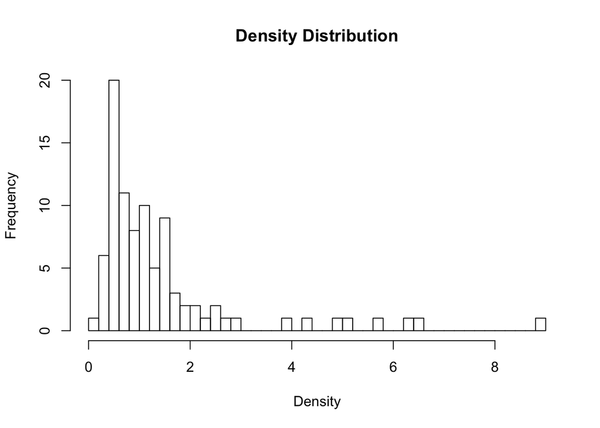

```r
hist(x = crime$density, breaks=50, main = "Density Distribution", xlab = "Density", ylab = "Frequency")
```

```r
summary(crime$density)
```

```
##    Min. 1st Qu.  Median    Mean 3rd Qu.    Max.
## 0.00002 0.54718 0.97925 1.43567 1.56926 8.82765
```

```r
crime[crime$density<0.0001,]
```

```
##    county year    crmrte   prbarr  prbconv prbpris avgsen      polpc
## 79    173   87 0.0139937 0.530435 0.327869    0.15   6.64 0.00316379
##        density    taxpc west central urban pctmin80    wcon     wtuc
## 79 2.03422e-05 37.72702    1       0     0  25.3914 231.696 213.6752
##        wtrd    wfir     wser   wmfg   wfed   wsta   wloc       mix
## 79 175.1604 267.094 204.3792 193.01 334.44 414.68 304.32 0.4197531
##       pctymle
## 79 0.07462687
```

Searching for the FIPS code of this county (173), we see that it is Swain County. When we search the data for Swain County in 1987 in the United States Census Bureau database, we see that the density was in fact 0.0202. That is clearly an arithmetic error, generating a value a 1000 times smaller. So, we correct it.

```r
crime$density[crime$density<0.0001]<- crime$density[crime$density<0.0001]*1000
crime[crime$county==173,]
```

```
##    county year    crmrte   prbarr  prbconv prbpris avgsen      polpc
## 79    173   87 0.0139937 0.530435 0.327869    0.15   6.64 0.00316379
##      density    taxpc west central urban pctmin80    wcon     wtuc
## 79 0.0203422 37.72702    1       0     0  25.3914 231.696 213.6752
##        wtrd    wfir     wser   wmfg   wfed   wsta   wloc       mix
## 79 175.1604 267.094 204.3792 193.01 334.44 414.68 304.32 0.4197531
##       pctymle
## 79 0.07462687
```

*Other clear outliers*

For the service industry wages, there is one observation in particular that catches the eye, which is way above the second largest value. For that, we take a deeper look

```r
crime[crime$wser>2000,]
```

```
##    county year    crmrte   prbarr prbconv  prbpris avgsen     polpc
## 84    185   87 0.0108703 0.195266 2.12121 0.442857   5.38 0.0012221
##      density    taxpc west central urban pctmin80     wcon    wtuc
## 84 0.3887588 40.82454    0       1     0  64.3482 226.8245 331.565
##        wtrd     wfir     wser   wmfg   wfed   wsta   wloc        mix
## 84 167.3726 264.4231 2177.068 247.72 381.33 367.25 300.13 0.04968944
##       pctymle
## 84 0.07008217
```

It is county 185, Warren County. The only sector that has a weekly wage so much higher than for the other counties is the service industry, with all other sectors having a weekly wage very close to the state average. One might wonder if this county is particularly attractive for tourism, or some other sort of services, to explain such a difference. That is not the fact: Warren county is a center of tobacco and cotton plantations, and textile mills (https://en.wikipedia.org/wiki/Warren_County,_North_Carolina). It is very likely the value is multiplied by 10, and the actual value is 217.7068 instead of 2177.068. However, since we cannot atest that with certainty, we will leave the value as it is, and will not discard the observation.